# The ETS Proficiency Profile at Georgetown College

August, 2014

## Introduction

## The ETS

- ETS Proficiency Profile
- Given annually to seniors at 252 four-year institutions
- Overall scaled score 400-500
- Four scaled subscores (100-125), in these areas:
  - Mathematics
  - Reading
  - Writing
  - Critical Thinking

[**Sample Questions Here**](https://www.ets.org/s/proficiencyprofile/pdf/sampleques.pdf)

In addition to scaled scores, the Profile attempts to assess proficiency in three areas:

- Reading and Critical Thinking
- Writing
- Mathematics

Assessment is made at each of three levels (Level 1,2 and 3) in each area.

[**More Info on Proficiency Here**](https://www.ets.org/proficiencyprofile/scores/proficiency_classifications/levels)

## At Georgetown

- The Proficiency Profile has been given each Spring since 2010.
- That's five senior cohorts!
- 800 out of about 1200 seniors have taken the exam.

## Questions

- *How does GC compare to other instituions?*
- *Have our scores changed over time?*
- *What are our proficiency ratings? Have they changed over time?*
- *Does one's academic major make a difference in one's ETS scores?*
- *Does race or sex make a difference in one's score?*

## Methods

## Adjust for Academic Preparation!

ETS performance determined largely by academic preparation (\(R^2 =\) 0.53):

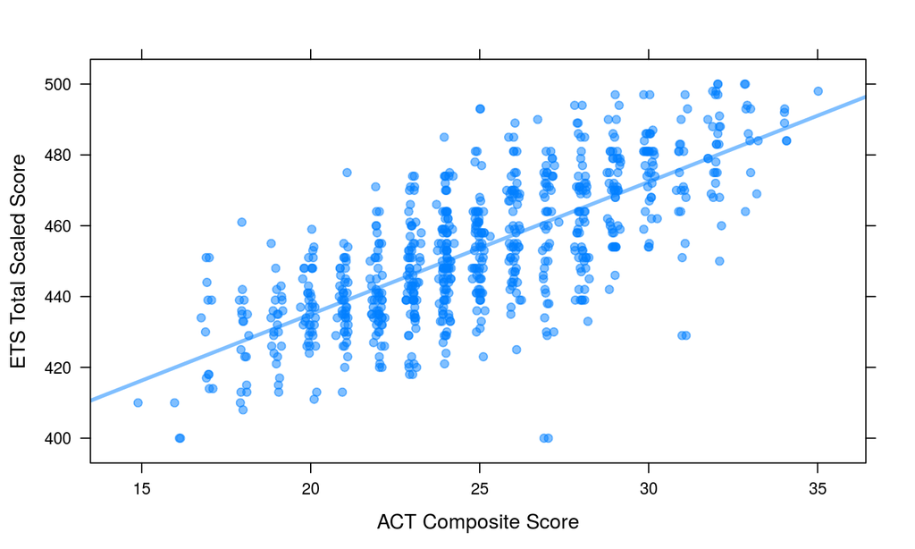

## Data Munging

For many of our questions, we would like to correct for differences in incoming academic preparation.

Accordingly, we merged the ETS data with a GC dataset that gives:

- College name of record
- ACT scores (composite and subscores)
- actual graduation year
- actual graduation major(s). (ETS asks students to pick from several "types" of major)

## Data Munging

Merging was not easy!

- Students often entered wrong ID number
- On ETS, students:
  - use nicknames
  - use new married name
  - spell name differently than GC does
  - don't graduate when they think they will
  - don't graduate at all

With a bit of computer programming, we ended up matching 738 of the 800 ETS students with their GC data.

## Linear Models

Example (in question about sex making difference in Total ETS score):

\[Total = \alpha + \beta_0 \times ACT = \beta_1 \times Female + \epsilon\]

- \(\alpha\) represents the predicted score for a student of average composite ACT and unknown sex.
- \(\beta_0\) tells how much your predicted score increases for each one-point increase in ACT Composite score.
- \(\beta_1\) represents the difference in score that is predicted for a female relative to a person with same ACT whose sex is not known.
- \(\epsilon\) is chance error.
- Note: we will be using "sum contrasts", not "treatment contrasts."

## Results

## National Comparison

Comparison with 252 institutions (2009-2013):

| Area | GC Mean | GC Percentile |
| --- | --- | --- |
| Math | 114.7 | 45 |
| Reading | 120.12 | 68 |
| Writing | 115.58 | 54 |
| Critical Thinking | 113.78 | 53 |
| Total | 451.28 | 70 |

But we do not know how our academic prep compares to that of other schools! Are we adding more value than they do? Or less?

## Our Scores Over Time

| Cohort | ETS Total Mean | ACT Composite Mean |
| --- | --- | --- |
| 2010 | 450.25 | 24.84 |
| 2011 | 454.69 | 24.88 |
| 2012 | 452.73 | 24.99 |
| 2013 | 454.58 | 24.8 |
| 2014 | 455.61 | 25.21 |

Notes:

- 2010 cohort stank (\(P \approx 0.015\))
- Our ACT scores are exaggerated!

## Writing Over Time

A question from Dr. Allen: *Do the new writing flags make a difference?*

| Cohort | ETS Writing Mean | ACT English Mean |
| --- | --- | --- |
| 2010 | 115.11 | 25.14 |
| 2011 | 115.95 | 25.79 |
| 2012 | 115.53 | 25.19 |
| 2013 | 116.43 | 25.02 |
| 2014 | 116.76 | 25.68 |

## Something Going On, Here?

```
##                        Estimate Std. Error  t value Pr(>|t|)
## Intercept              115.2226     0.2938 392.1621   0.0000
## English ACT (centered)   0.4652     0.0288  16.1341   0.0000
## 2011                     0.5341     0.4405   1.2124   0.2257
## 2012                     0.3886     0.4508   0.8619   0.3890
## 2013                     1.3662     0.4480   3.0496   0.0024
## 2014                     1.3922     0.4249   3.2768   0.0011
```

A small but significant bump in the last two years: being in 2013 or 2014 cohort increases your predicted ETS Writing score by 1 to 1.4 points over members of previous cohorts with the same English ACT.

Note: "treatment" contrasts here. Comparisons are with the 2010 cohort treated as baseline.

## Proficiency: Math Level 3

Students should be able to:

- solve word problems that would be unlikely to be solved by arithmetic …
- solve problems involving difficult arithmetic concepts, such as exponents and roots other than squares and square roots …
- generalize about numbers (e.g., identify the values of (x) for which an expression increases as (x) increases)
- solve problems requiring an understanding of the properties of integers, rational numbers, etc.
- interpret a graph in which the trends are to be expressed algebraically or one of the following is involved: exponents and roots other than squares and square roots, percent of increase or decrease
- solve problems requiring insight or logical reasoning

[**Adapted from here**](https://www.ets.org/proficiencyprofile/scores/proficiency_classifications/levels)

## Proficiency: Math Level 3

Percentages at each proficiency level, by cohort:

```
##      1_Not_Prof 2_Marginally_Prof 3_Proficient Total
## 2010      16.28             73.26        10.47   100
## 2011      19.58             68.53        11.89   100
## 2012      18.18             69.23        12.59   100
## 2013      18.06             68.06        13.89   100
## 2014      26.77             63.64         9.60   100
```

## Proficiency: Crticial Thinking

This is Level 3 of the Reading proficiency levels. To be proficient at this level student must be able to:

- evaluate competing causal explanations
- evaluate hypotheses for consistency with known facts
- determine the relevance of information for evaluating an argument or conclusion
- determine whether an artistic interpretation is supported by evidence contained in a work
- evaluate the appropriateness of procedures for investigating a question of causation
- evaluate data for consistency with known facts, hypotheses or methods
- recognize flaws and inconsistencies in an argument

[**Adapted from here**](https://www.ets.org/proficiencyprofile/scores/proficiency_classifications/levels)

## Proficiency: Critical Thinking

Percentages at each proficiency level, by cohort:

```
##      1_Not_Prof 2_Marginally_Prof 3_Proficient Total
## 2010      25.00             68.02         6.98   100
## 2011      27.27             62.24        10.49   100
## 2012      27.97             62.94         9.09   100
## 2013      34.03             57.64         8.33   100
## 2014      30.81             57.58        11.62   100
```

## Proficiency: Writing Level 3

To be proficient at this level student must be able to:

- discriminate between appropriate and inappropriate use of parallelism
- discriminate between appropriate and inappropriate use of idiomatic language
- recognize redundancy
- discriminate between correct and incorrect constructions
- recognize the most effective revision of a sentence

[**Adapted from here**](https://www.ets.org/proficiencyprofile/scores/proficiency_classifications/levels)

## Proficiency: Writing Level 3

Percentages at each proficiency level, by cohort:

```
##      1_Not_Prof 2_Marginally_Prof 3_Proficient Total
## 2010      23.26             66.28        10.47   100
## 2011      34.27             54.55        11.19   100
## 2012      25.87             64.34         9.79   100
## 2013      34.03             54.17        11.81   100
## 2014      33.33             53.54        13.13   100
```

## Major, Sex, and Race

Try this link on your mobile device:

http://homer.shinyapps.io/shinyETS

Or this one (same app):

http://rstudio.georgetowncollege.edu:3838/shinyETS

## Conclusion

## Future Data Collection

Proctor the ETS more carefully:

- Make sure student enter correct ID
- guard against fraud

## Cautions

- Sometimes our results are "statistically significant"
- But we are guilty of some "data snooping"
- Also, we made many, many comparisons, obtained many P-values
- These need to be adjusted for multiple comparisons
- Probably won't be able to draw firm conclusions right now
- (except that: for the most part, nothing is going on!)
- Need to "watch" certain patterns
- Gather more data over the years, see if "watched" patterns persist

## Confounding (example)

Students have no vested interest in doing well on the ETS.

If students differ by major in the amount of effort they choose to put forth …

… then differences in performance by major could be due to differences in "student academic culture", not growth in academic ability.

## Assessment: a Black Hole?

May need 6-8 more years before we can be sure of "suspected" patterns …

… and by then, underlying conditions at GC may have changed!

So: **how do we use the data to improve our programs?**